# Template code for logistic regression and ggplot (for bee data analysis)

## Dredge

What should you do when your model is quite complex and you’re not sure which variables or interactions to include? The dredge function helps evaluate all possible combinations of predictor variables and interactions to help determine which model is the best fit for your data. Dredge then ranks your models based on AICc.For example, here I included a few other variables in my full model, then the dredge function should tell you that the intercept only model is the best fit. The ‘+’ symbol indicates what you should keep in the model and a blank space means that the model ommited the variable.

Note, when selecting which predictors to keep, you should largely make choices based on your existing hypothesis e.g. theres no point in cutting temperature if your study is looking at temperature effects specifically.

```r
Full_model <- glmer(CHOICE~  + TRIAL + TEMPERATURE + URBAN_GRAD + TEMPERATURE*URBAN_GRAD*TRIAL + (1|BEEID), family = binomial, data = btest)
```

```
## boundary (singular) fit: see help('isSingular')
```

```r
summary(Full_model)
```

```
## Generalized linear mixed model fit by maximum likelihood (Laplace
##   Approximation) [glmerMod]
##  Family: binomial  ( logit )
## Formula:
## CHOICE ~ +TRIAL + TEMPERATURE + URBAN_GRAD + TEMPERATURE * URBAN_GRAD *
##     TRIAL + (1 | BEEID)
##    Data: btest
##
##      AIC      BIC   logLik deviance df.resid
##    154.3    205.6    -58.2    116.3       91
##
## Scaled residuals:
##     Min      1Q  Median      3Q     Max
## -2.0220 -1.0076  0.4960  0.6755  1.0622
##
## Random effects:
##  Groups Name        Variance Std.Dev.
##  BEEID  (Intercept) 0        0
## Number of obs: 110, groups:  BEEID, 11
##
## Fixed effects:
##                                               Estimate Std. Error z value
## (Intercept)                                     0.1799     1.5782   0.114
## TRIAL                                           0.2457     0.3094   0.794
## TEMPERATURELOW                                 -0.1126     2.1368  -0.053
## TEMPERATUREMODERATE                             0.4840     1.9094   0.254
## URBAN_GRADMODERATE                             -0.3285     1.8573  -0.177
## URBAN_GRADURBAN                               255.5100   175.6157   1.455
## TEMPERATURELOW:URBAN_GRADMODERATE               0.4411     2.8311   0.156
## TEMPERATUREMODERATE:URBAN_GRADMODERATE         -0.7682     2.5613  -0.300
## TEMPERATURELOW:URBAN_GRADURBAN               -254.5697   175.6206  -1.450
## TEMPERATUREMODERATE:URBAN_GRADURBAN          -256.1066   175.6236  -1.458
## TRIAL:TEMPERATURELOW                           -0.0973     0.3981  -0.244
## TRIAL:TEMPERATUREMODERATE                      -0.1641     0.3591  -0.457
## TRIAL:URBAN_GRADMODERATE                       -0.1434     0.3493  -0.410
## TRIAL:URBAN_GRADURBAN                         -34.3445   213.5188  -0.161
## TRIAL:TEMPERATURELOW:URBAN_GRADMODERATE         0.2407     0.5296   0.454
## TRIAL:TEMPERATUREMODERATE:URBAN_GRADMODERATE    0.2179     0.4586   0.475
## TRIAL:TEMPERATURELOW:URBAN_GRADURBAN           34.1672   213.5188   0.160
## TRIAL:TEMPERATUREMODERATE:URBAN_GRADURBAN      34.4113   213.5190   0.161
##                                              Pr(>|z|)
## (Intercept)                                     0.909
## TRIAL                                           0.427
## TEMPERATURELOW                                  0.958
## TEMPERATUREMODERATE                             0.800
## URBAN_GRADMODERATE                              0.860
## URBAN_GRADURBAN                                 0.146
## TEMPERATURELOW:URBAN_GRADMODERATE               0.876
## TEMPERATUREMODERATE:URBAN_GRADMODERATE          0.764
## TEMPERATURELOW:URBAN_GRADURBAN                  0.147
## TEMPERATUREMODERATE:URBAN_GRADURBAN             0.145
## TRIAL:TEMPERATURELOW                            0.807
## TRIAL:TEMPERATUREMODERATE                       0.648
## TRIAL:URBAN_GRADMODERATE                        0.681
## TRIAL:URBAN_GRADURBAN                           0.872
## TRIAL:TEMPERATURELOW:URBAN_GRADMODERATE         0.650
## TRIAL:TEMPERATUREMODERATE:URBAN_GRADMODERATE    0.635
## TRIAL:TEMPERATURELOW:URBAN_GRADURBAN            0.873
## TRIAL:TEMPERATUREMODERATE:URBAN_GRADURBAN       0.872
```

```
##
## Correlation matrix not shown by default, as p = 18 > 12.
## Use print(x, correlation=TRUE)  or
##     vcov(x)        if you need it
```

```
## optimizer (Nelder_Mead) convergence code: 0 (OK)
## boundary (singular) fit: see help('isSingular')
```

```r
options(na.action = na.fail)
glmdredge <- dredge(Full_model)
```

[output not shown]

```r
glmdredge
```

```
## Global model call: glmer(formula = CHOICE ~ +TRIAL + TEMPERATURE + URBAN_GRAD +
##     TEMPERATURE * URBAN_GRAD * TRIAL + (1 | BEEID), data = btest,
##     family = binomial)
## ---
## Model selection table
##      (Int) TEM      TRI URB_GRA TEM:TRI TEM:URB_GRA TRI:URB_GRA TEM:TRI:URB_GRA
## 1   0.8473
## 3   0.5764      0.05001
## 5   1.0990                    +
## 2   0.7309   +
## 7   0.8264      0.05045       +
## 4   0.4588   +  0.05014
## 39  0.4068      0.13230       +                               +
## 6   1.0460   +                +
## 12  1.0010   + -0.04849               +
```

[output cut: 33 more lines]

```r
options(na.action = na.omit)
```

## Changing reference level for GLMMs with factors

```r
Temp_model <- glmer(CHOICE ~ TEMPERATURE + (1|BEEID), family = binomial, data = btest)
```

```
## boundary (singular) fit: see help('isSingular')
```

```r
summary(Temp_model)
```

```
## Generalized linear mixed model fit by maximum likelihood (Laplace
##   Approximation) [glmerMod]
##  Family: binomial  ( logit )
## Formula: CHOICE ~ TEMPERATURE + (1 | BEEID)
##    Data: btest
##
##      AIC      BIC   logLik deviance df.resid
##    142.1    152.9    -67.1    134.1      106
##
## Scaled residuals:
##     Min      1Q  Median      3Q     Max
## -1.6583 -1.4411  0.6288  0.6546  0.6939
##
## Random effects:
##  Groups Name        Variance  Std.Dev.
##  BEEID  (Intercept) 1.019e-15 3.191e-08
## Number of obs: 110, groups:  BEEID, 11
##
## Fixed effects:
##                     Estimate Std. Error z value Pr(>|z|)
## (Intercept)           0.7309     0.3376   2.165   0.0304 *
## TEMPERATURELOW        0.2807     0.5333   0.526   0.5986
## TEMPERATUREMODERATE   0.1164     0.4827   0.241   0.8094
## ---
## Signif. codes:  0 '***' 0.001 '**' 0.01 '*' 0.05 '.' 0.1 ' ' 1
##
## Correlation of Fixed Effects:
##              (Intr) TEMPERATUREL
## TEMPERATUREL -0.633
## TEMPERATUREM -0.699  0.443
## optimizer (Nelder_Mead) convergence code: 0 (OK)
## boundary (singular) fit: see help('isSingular')
```

```r
btest$TEMPERATURE <- factor(btest$TEMPERATURE)
btest$TEMPERATURE <- relevel(btest$TEMPERATURE, ref = "LOW")
Temp_model2 <- glmer(CHOICE ~ TEMPERATURE + (1|BEEID), family = binomial, data = btest)
```

```
## boundary (singular) fit: see help('isSingular')
```

```r
summary(Temp_model2)
```

```
## Generalized linear mixed model fit by maximum likelihood (Laplace
##   Approximation) [glmerMod]
##  Family: binomial  ( logit )
## Formula: CHOICE ~ TEMPERATURE + (1 | BEEID)
##    Data: btest
##
##      AIC      BIC   logLik deviance df.resid
##    142.1    152.9    -67.1    134.1      106
##
## Scaled residuals:
##     Min      1Q  Median      3Q     Max
## -1.6583 -1.4411  0.6288  0.6546  0.6939
##
## Random effects:
##  Groups Name        Variance Std.Dev.
##  BEEID  (Intercept) 0        0
## Number of obs: 110, groups:  BEEID, 11
##
## Fixed effects:
##                     Estimate Std. Error z value Pr(>|z|)
## (Intercept)           1.0116     0.4129   2.450   0.0143 *
## TEMPERATUREHIGH      -0.2807     0.5333  -0.526   0.5986
## TEMPERATUREMODERATE  -0.1643     0.5381  -0.305   0.7601
## ---
## Signif. codes:  0 '***' 0.001 '**' 0.01 '*' 0.05 '.' 0.1 ' ' 1
##
## Correlation of Fixed Effects:
##              (Intr) TEMPERATUREH
## TEMPERATUREH -0.774
## TEMPERATUREM -0.767  0.594
## optimizer (Nelder_Mead) convergence code: 0 (OK)
## boundary (singular) fit: see help('isSingular')
```

## Assumption checking

Remember to check model assumptions for each model. This can be done use the ‘performance’ package with the following code:

[figure not shown]

```r
performance::check_model(traininglm, check = c("qq", "outliers","reqq","binned_residuals"))
```

```r
binned_residuals(traininglm)
```

```
## Ok: About 95% of the residuals are inside the error bounds.
```

```r
check_convergence(traininglm)
```

```
## `check_convergence()` does not work for models of class 'glm'.
```

```r
check_overdispersion(traininglm)
```

```
## # Overdispersion test
##
##  dispersion ratio = 1.006
##           p-value = 0.944
```

```
## No overdispersion detected.
```

```r
modperm<- model_performance(traininglm)
display(modperm, format = "markdown", digits = 2, caption = NULL)
```

| AIC | AICc | BIC | Tjur’s R2 | RMSE | Sigma | Log_loss | Score_log | Score_spherical | PCP |
| --- | --- | --- | --- | --- | --- | --- | --- | --- | --- |
| 476.49 | 476.59 | 492.45 | 0.07 | 0.45 | 1.00 | 0.59 | -340.59 | 7.08e-03 | 0.60 |

Note that for binomial data, the residuals can’t follow a normal distribution as they are restricted to the interval [0,1]. If comparing between models, use the AIC to select the best model (models with the lowest scores are better). See https://easystats.github.io/performance/#comprehensive-visualization-of-model-checks for further details. Also note that if you are using an intercept only model then you don’t really need to check for assumptions as you are mainly focussing on the intercept term and it’s confidence interval.

We also should check the linearity assumption for logistic regression: there should be a roughly linear relationship between the predictor and the log odds of an outcome. We can simply graph this and see if there is a linear relationship.

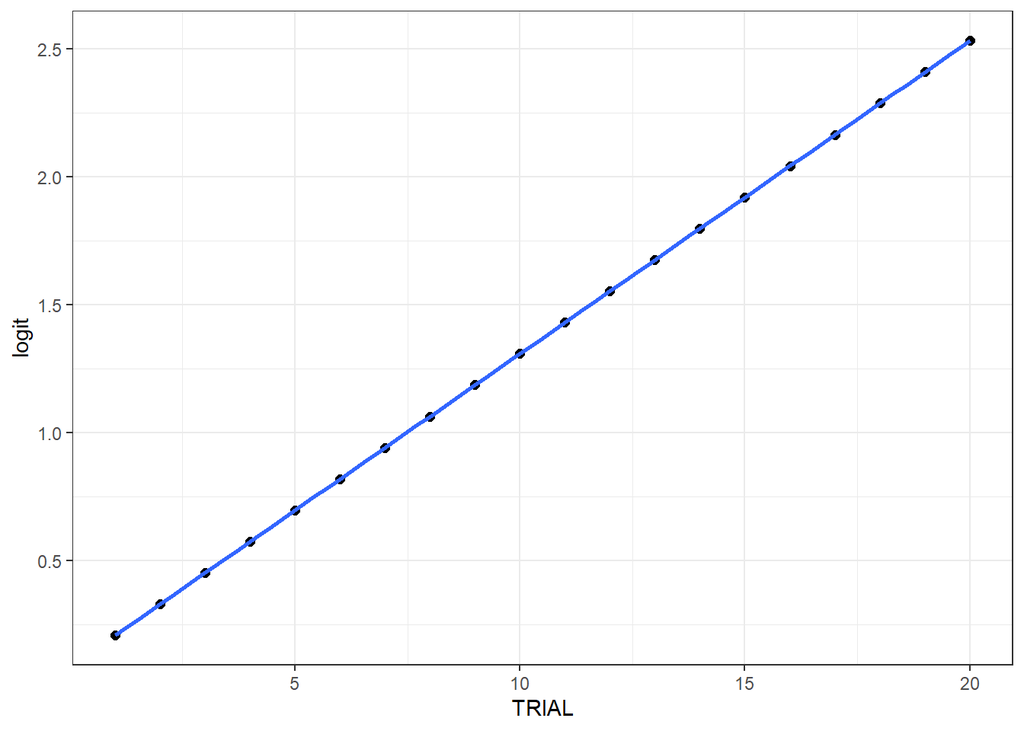

```r
probabilities <- predict(btraininglm, type = "response")
logit = log(probabilities/(1-probabilities))

ggplot(btraining, aes(TRIAL, logit)) +
  geom_point(size = 2, alpha = 0.5, colour = "black") +
  geom_smooth(method = "loess") +
  theme_bw()
```

Finally, We can use the DHARMa package to assess the goodness of fit of the model. DHARMa does this by simulating residuals from your model and comparing these residuals with your actual observed residuals. This will help identify if your model has a good fit with the observed data.

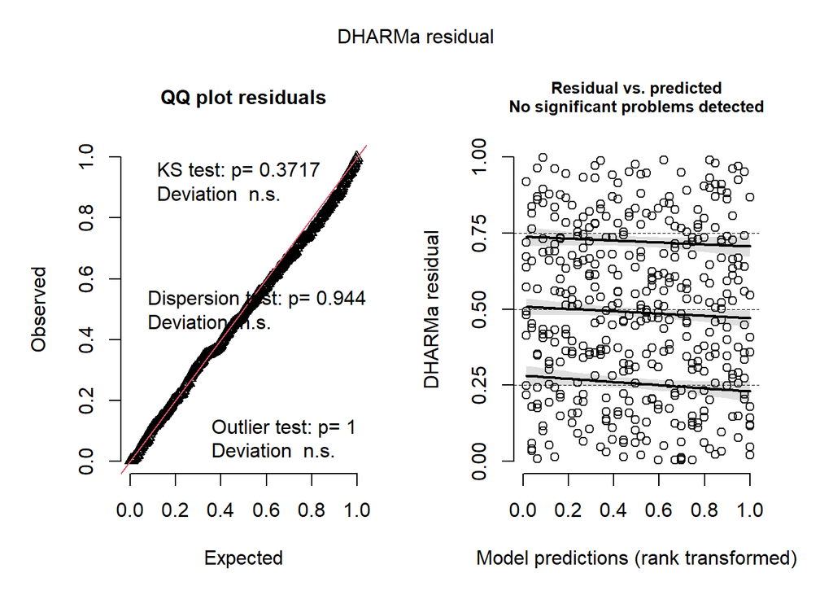

```r
simulated_res <- simulateResiduals(fittedModel = traininglm)
plot(simulated_res)
```

These graphs will also help you identify deviations from normality assumptions. If there is nothing wrong with the simulated residuals, it means that the observed data likely originated from the fitted model. Specifically, a flat residual distribution shows that your data fits the model. See: https://cran.r-project.org/web/packages/DHARMa/vignettes/DHARMa.html for further details.

## Transformations

Sometimes you may have to transform your data if your model does not meet its assumptions and your predictor variable is continuous e.g. duration. The following are some simple transformations you can try. After you try each one, run the assumption tests again to see if this has fixed the problem.

```r
btest$log_RESPONSE_TIME <- log(btest$RESPONSE_TIME) # log transform
btest$sqrt_RESPONSE_TIME <- sqrt(btest$RESPONSE_TIME) # square root
btest$inv_RESPONSE_TIME <- 1/btest$RESPONSE_TIME # inverse transformation
```

## Posthoc investigation of interactions

If you find a significant interaction effect between two variables which are both factors with multiple levels, it is important to conduct posthoc analyses to help interpret this interaction. For example, the emmeans R package allows you to calculate estimated marginal means (EMMs), which are model-based predicted values of the response for each level or combination of predictors, while accounting for the other variables in the model.

To illustrate this let’s generate a hypothetical model

```r
Hypo_model <- glmer(CHOICE~  + TEMPERATURE*URBAN_GRAD + (1|BEEID), family = binomial, data = btest)
```

```
## boundary (singular) fit: see help('isSingular')
```

Now in this example, TEMPERATURE is either HIGH, MODERATE or LOW, and URBAN_GRAD is either LOW, MODERATE, or URBAN. If there was an interaction between TEMPERATURE and URBAN_GRAD, then emmeans helps you break this down by asking questions such as “What is the effect of TEMPERATURE within each URBAN_GRAD level?” or conversely “What is the effect of URBAN_GRAD at each level of TEMPERATURE?”. Rather than calculating raw means from the data, emmeans uses the fitted model to generate predicted values, which represent the expected response (e.g., probability in a logistic regression) for each combination of conditions. This makes it easier to interpret the interaction in terms of differences in predicted outcomes between groups.

```r
emmeans(Hypo_model, pairwise ~ TEMPERATURE | URBAN_GRAD) # What is the effect if temperature within each urban gradient e.g. if urban gradient is low, what is the difference between high and low temperature bees
```

```
## $emmeans
## URBAN_GRAD = LOW:
##  TEMPERATURE emmean    SE  df asymp.LCL asymp.UCL
##  LOW          0.847 0.690 Inf   -0.5052      2.20
##  HIGH         1.386 0.791 Inf   -0.1632      2.94
##  MODERATE     1.099 0.516 Inf    0.0865      2.11
##
## URBAN_GRAD = MODERATE:
##  TEMPERATURE emmean    SE  df asymp.LCL asymp.UCL
##  LOW          1.386 0.791 Inf   -0.1632      2.94
##  HIGH         0.405 0.456 Inf   -0.4891      1.30
##  MODERATE     0.405 0.645 Inf   -0.8597      1.67
##
## URBAN_GRAD = URBAN:
##  TEMPERATURE emmean    SE  df asymp.LCL asymp.UCL
##  LOW          0.847 0.690 Inf   -0.5052      2.20
##  HIGH         0.847 0.690 Inf   -0.5052      2.20
##  MODERATE     0.847 0.690 Inf   -0.5052      2.20
##
## Results are given on the logit (not the response) scale.
## Confidence level used: 0.95
##
## $contrasts
## URBAN_GRAD = LOW:
##  contrast        estimate    SE  df z.ratio p.value
##  LOW - HIGH        -0.539 1.049 Inf  -0.514  0.8647
##  LOW - MODERATE    -0.251 0.862 Inf  -0.292  0.9542
##  HIGH - MODERATE    0.288 0.944 Inf   0.305  0.9501
##
## URBAN_GRAD = MODERATE:
##  contrast        estimate    SE  df z.ratio p.value
##  LOW - HIGH         0.981 0.913 Inf   1.074  0.5300
##  LOW - MODERATE     0.981 1.021 Inf   0.961  0.6016
##  HIGH - MODERATE    0.000 0.791 Inf   0.000  1.0000
##
## URBAN_GRAD = URBAN:
##  contrast        estimate    SE  df z.ratio p.value
##  LOW - HIGH         0.000 0.976 Inf   0.000  1.0000
##  LOW - MODERATE     0.000 0.976 Inf   0.000  1.0000
##  HIGH - MODERATE    0.000 0.976 Inf   0.000  1.0000
##
## Results are given on the log odds ratio (not the response) scale.
## P value adjustment: tukey method for comparing a family of 3 estimates
```

```r
emmeans(Hypo_model, pairwise ~ URBAN_GRAD | TEMPERATURE) # What is the effect of urban gradient within each temperature level
```

```
## $emmeans
## TEMPERATURE = LOW:
##  URBAN_GRAD emmean    SE  df asymp.LCL asymp.UCL
##  LOW         0.847 0.690 Inf   -0.5052      2.20
##  MODERATE    1.386 0.791 Inf   -0.1632      2.94
##  URBAN       0.847 0.690 Inf   -0.5052      2.20
##
## TEMPERATURE = HIGH:
##  URBAN_GRAD emmean    SE  df asymp.LCL asymp.UCL
##  LOW         1.386 0.791 Inf   -0.1632      2.94
##  MODERATE    0.405 0.456 Inf   -0.4891      1.30
##  URBAN       0.847 0.690 Inf   -0.5052      2.20
##
## TEMPERATURE = MODERATE:
##  URBAN_GRAD emmean    SE  df asymp.LCL asymp.UCL
##  LOW         1.099 0.516 Inf    0.0865      2.11
##  MODERATE    0.405 0.645 Inf   -0.8597      1.67
##  URBAN       0.847 0.690 Inf   -0.5052      2.20
##
## Results are given on the logit (not the response) scale.
## Confidence level used: 0.95
##
## $contrasts
## TEMPERATURE = LOW:
##  contrast         estimate    SE  df z.ratio p.value
##  LOW - MODERATE     -0.539 1.049 Inf  -0.514  0.8647
##  LOW - URBAN         0.000 0.976 Inf   0.000  1.0000
##  MODERATE - URBAN    0.539 1.049 Inf   0.514  0.8647
##
## TEMPERATURE = HIGH:
##  contrast         estimate    SE  df z.ratio p.value
##  LOW - MODERATE      0.981 0.913 Inf   1.074  0.5300
##  LOW - URBAN         0.539 1.049 Inf   0.514  0.8647
##  MODERATE - URBAN   -0.442 0.827 Inf  -0.534  0.8546
##
## TEMPERATURE = MODERATE:
##  contrast         estimate    SE  df z.ratio p.value
##  LOW - MODERATE      0.693 0.827 Inf   0.839  0.6790
##  LOW - URBAN         0.251 0.862 Inf   0.292  0.9542
##  MODERATE - URBAN   -0.442 0.945 Inf  -0.468  0.8865
##
## Results are given on the log odds ratio (not the response) scale.
## P value adjustment: tukey method for comparing a family of 3 estimates
```

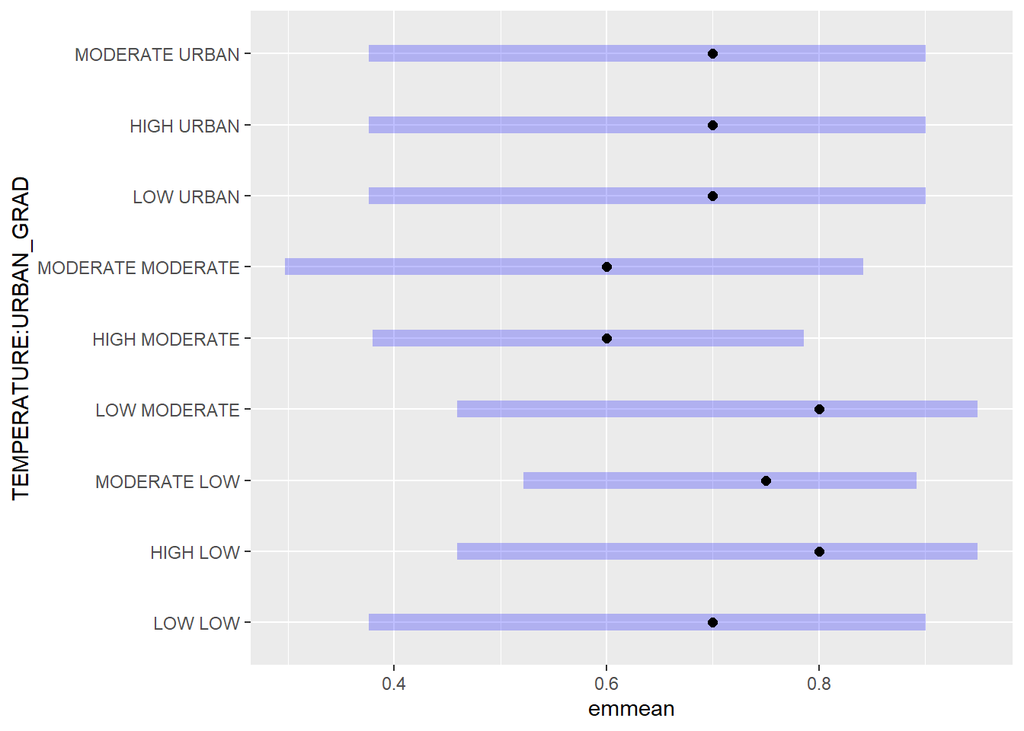

```r
plot(emmeans(Hypo_model, ~ TEMPERATURE * URBAN_GRAD, type = "response")) # Visualize, the model-estimated probability of a correct choice for each combination of temperature and urban gradient level.
```

If you have one categorical and one continuous variable as an interaction, you could also use emmeans by converting your continuous variable into categories. Alternatively use the emtrends function to compare if slopes differ significantly from each other?

```r
Hypo_model2 <- glmer(CHOICE~  + TRIAL*URBAN_GRAD + (1|BEEID), family = binomial, data = btest)
```

```
## boundary (singular) fit: see help('isSingular')
```

```r
emmeans(Hypo_model2,
        pairwise ~ URBAN_GRAD | TRIAL,
        at = list(TRIAL = c(1, 10, 20))) # What is the effect of urban gradient at Trial 1, 10 or 20
```

```
## $emmeans
## TRIAL =  1:
##  URBAN_GRAD  emmean    SE  df asymp.LCL asymp.UCL
##  LOW         0.5391 0.639 Inf  -0.71416      1.79
##  MODERATE    0.0285 0.601 Inf  -1.15005      1.21
##  URBAN       1.6570 0.844 Inf   0.00294      3.31
##
## TRIAL = 10:
##  URBAN_GRAD  emmean    SE  df asymp.LCL asymp.UCL
##  LOW         1.7297 0.759 Inf   0.24214      3.22
##  MODERATE    1.2552 0.669 Inf  -0.05509      2.57
##  URBAN       0.1312 0.708 Inf  -1.25718      1.52
##
## TRIAL = 20:
##  URBAN_GRAD  emmean    SE  df asymp.LCL asymp.UCL
##  LOW         3.0526 2.013 Inf  -0.89231      7.00
##  MODERATE    2.6181 1.804 Inf  -0.91702      6.15
##  URBAN      -1.5641 2.084 Inf  -5.64788      2.52
##
## Results are given on the logit (not the response) scale.
## Confidence level used: 0.95
##
## $contrasts
## TRIAL =  1:
##  contrast         estimate    SE  df z.ratio p.value
##  LOW - MODERATE      0.511 0.878 Inf   0.582  0.8299
##  LOW - URBAN        -1.118 1.059 Inf  -1.056  0.5416
##  MODERATE - URBAN   -1.628 1.036 Inf  -1.572  0.2580
##
## TRIAL = 10:
##  contrast         estimate    SE  df z.ratio p.value
##  LOW - MODERATE      0.475 1.011 Inf   0.469  0.8858
##  LOW - URBAN         1.598 1.038 Inf   1.540  0.2724
##  MODERATE - URBAN    1.124 0.974 Inf   1.154  0.4809
##
## TRIAL = 20:
##  contrast         estimate    SE  df z.ratio p.value
##  LOW - MODERATE      0.434 2.703 Inf   0.161  0.9859
##  LOW - URBAN         4.617 2.897 Inf   1.594  0.2483
##  MODERATE - URBAN    4.182 2.756 Inf   1.518  0.2826
##
## Results are given on the log odds ratio (not the response) scale.
## P value adjustment: tukey method for comparing a family of 3 estimates
```

```r
emtrends(Hypo_model2, pairwise ~ URBAN_GRAD, var = "TRIAL") # do slopes differ significantly from each other?
```

```
## $emtrends
##  URBAN_GRAD TRIAL.trend    SE  df asymp.LCL asymp.UCL
##  LOW              0.132 0.132 Inf   -0.1256     0.390
##  MODERATE         0.136 0.119 Inf   -0.0978     0.370
##  URBAN           -0.170 0.146 Inf   -0.4565     0.117
##
## Confidence level used: 0.95
##
## $contrasts
##  contrast         estimate    SE  df z.ratio p.value
##  LOW - MODERATE   -0.00401 0.178 Inf  -0.023  0.9997
##  LOW - URBAN       0.30182 0.197 Inf   1.533  0.2753
##  MODERATE - URBAN  0.30583 0.189 Inf   1.618  0.2378
##
## P value adjustment: tukey method for comparing a family of 3 estimates
```

## Test data

Now let’s analyse the test data, usually this is a bit different because you are equally interested in all 10-20 unrewarded choices rather than the effect of trial number. Because of this, we can run an intercept-only model; in logistic regression an intercept only model compares the choice distribution to a 50% chance level. Again, we can see the singular boundary error (see above), again you can choose to keep or simplify the model.

```r
bluelm <- glmer(CHOICE~ 1 + (1|BEEID), family = binomial, data = btest)
```

```
## boundary (singular) fit: see help('isSingular')
```

```r
summary(bluelm)
```

```
## Generalized linear mixed model fit by maximum likelihood (Laplace
##   Approximation) [glmerMod]
##  Family: binomial  ( logit )
## Formula: CHOICE ~ 1 + (1 | BEEID)
##    Data: btest
##
##      AIC      BIC   logLik deviance df.resid
##    138.4    143.8    -67.2    134.4      108
##
## Scaled residuals:
##     Min      1Q  Median      3Q     Max
## -1.5275 -1.5275  0.6546  0.6546  0.6546
##
## Random effects:
##  Groups Name        Variance Std.Dev.
##  BEEID  (Intercept) 0        0
## Number of obs: 110, groups:  BEEID, 11
##
## Fixed effects:
##             Estimate Std. Error z value Pr(>|z|)
## (Intercept)   0.8473     0.2081   4.072 4.65e-05 ***
## ---
## Signif. codes:  0 '***' 0.001 '**' 0.01 '*' 0.05 '.' 0.1 ' ' 1
## optimizer (Nelder_Mead) convergence code: 0 (OK)
## boundary (singular) fit: see help('isSingular')
```

```r
yellowlm <- glmer(CHOICE~ 1 + (1|BEEID), family = binomial, data = ytest)
```

```
## boundary (singular) fit: see help('isSingular')
```

```r
summary(yellowlm)
```

```
## Generalized linear mixed model fit by maximum likelihood (Laplace
##   Approximation) [glmerMod]
##  Family: binomial  ( logit )
## Formula: CHOICE ~ 1 + (1 | BEEID)
##    Data: ytest
##
##      AIC      BIC   logLik deviance df.resid
##    136.8    142.0    -66.4    132.8       98
##
## Scaled residuals:
##     Min      1Q  Median      3Q     Max
## -1.2773 -1.2773  0.7829  0.7829  0.7829
##
## Random effects:
##  Groups Name        Variance Std.Dev.
##  BEEID  (Intercept) 0        0
## Number of obs: 100, groups:  BEEID, 10
##
## Fixed effects:
##             Estimate Std. Error z value Pr(>|z|)
## (Intercept)   0.4895     0.2060   2.376   0.0175 *
## ---
## Signif. codes:  0 '***' 0.001 '**' 0.01 '*' 0.05 '.' 0.1 ' ' 1
## optimizer (Nelder_Mead) convergence code: 0 (OK)
## boundary (singular) fit: see help('isSingular')
```

```r
bluelm2 <- glm(CHOICE~ 1, family = binomial, data = btest) # simplified model
summary(bluelm2)
```

```
##
## Call:
## glm(formula = CHOICE ~ 1, family = binomial, data = btest)
##
## Coefficients:
##             Estimate Std. Error z value Pr(>|z|)
## (Intercept)   0.8473     0.2081   4.072 4.65e-05 ***
## ---
## Signif. codes:  0 '***' 0.001 '**' 0.01 '*' 0.05 '.' 0.1 ' ' 1
##
## (Dispersion parameter for binomial family taken to be 1)
##
##     Null deviance: 134.39  on 109  degrees of freedom
## Residual deviance: 134.39  on 109  degrees of freedom
## AIC: 136.39
##
## Number of Fisher Scoring iterations: 4
```

```r
yellowlm2 <- glm(CHOICE~ 1, family = binomial, data = ytest)
summary(yellowlm2)
```

```
##
## Call:
## glm(formula = CHOICE ~ 1, family = binomial, data = ytest)
##
## Coefficients:
##             Estimate Std. Error z value Pr(>|z|)
## (Intercept)   0.4895     0.2060   2.376   0.0175 *
## ---
## Signif. codes:  0 '***' 0.001 '**' 0.01 '*' 0.05 '.' 0.1 ' ' 1
##
## (Dispersion parameter for binomial family taken to be 1)
##
##     Null deviance: 132.81  on 99  degrees of freedom
## Residual deviance: 132.81  on 99  degrees of freedom
## AIC: 134.81
##
## Number of Fisher Scoring iterations: 4
```

Let’s calculate confidence intervals which are required for subsequent figures. Note that the output are in the log-scale because of the logit link function, therefore we can reverse the link function to get meaningful values. You do this by first running the confint command to find the confidence intervals. Since we are analysing an intercept only model, we look at the 2.5% and 97.5% confidence bounds for the intercept. We then take this value and input it the reverse link function formula as shown below, do this for both the upper and lower bounds. We then save these values as confintlow or confinthigh so we can use these values in subsequent code.

```r
confint(bluelm) #confidence interval
```

```
## Computing profile confidence intervals ...
```

```
##                 2.5 %    97.5 %
## .sig01      0.0000000 0.5457291
## (Intercept) 0.4491324 1.2676763
```

```r
bconfintlow<-(exp(0.4491324)/(1 + exp(0.4491324))) #reverse link function
bconfinthigh<-(exp(1.2676763)/(1 + exp(1.2676763)))
print(bconfinthigh)
```

```
## [1] 0.7803447
```

```r
print(bconfintlow)
```

```
## [1] 0.6104329
```

```r
confint(yellowlm)
```

```
## Computing profile confidence intervals ...
```

```
##                  2.5 %    97.5 %
## .sig01      0.00000000 0.6013464
## (Intercept) 0.09087126 0.9010195
```

```r
yconfintlow <-(exp(0.09087126)/(1 + exp(0.09087126)))
yconfinthigh<-(exp(0.9010195)/(1 + exp(0.9010195)))
```